# BOA Run Segment Google Trends Searches

MM

9/22/2021

```r
knitr::opts_chunk$set(echo = TRUE)
```

## Load required packages:

```r
library(tinytex)
library(gtrendsR)
library(tidyverse)
library(lubridate)
library(ggplot2)
library(gridExtra)
library(readr)
library(gtrendsR)
library(purrr)
```

# Google Trends Keyword Data:

- Normalized to the highest search volume for each keyword within the time frame analyzed
- Search “interest” for each keyword scaled between 0 - 100
- Valuable for interest in specific terms over time, but not really useful for comparing the absolute popularity of different search terms relative to one another

## Pros & cons of using this scraping function in R vs. the Goole Trends interface:

- Pro: Can scrape more than the Google-Trends-interface limit of 5 keywords
- Con: Keywords are normalized to their own maximal popularity across the time frame analyzed, rather than normalized to all keywords in a given search

## Write function to scrape data from Google Trends for list of keywords:

```r
# The function wrap all the arguments of the gtrendR::trends function and return only the interest_over_time
googleTrendsData <- function (keywords) {

  # Set the geographic region, time span, etc.
  country <- c("US")
  time <- ("2016-01-01 2021-09-21")
  channel <- 'web'

  trends <- gtrends(keywords,
                   gprop = channel,
                   geo = country,
                   time = time )

  results <- trends$interest_over_time
  }
```

## Load keywords list (.csv file):

```r
kwlist <- readLines("KWlist_BOARunning.csv")
kwlist
```

```
##  [1] "BOA running shoes"       "BOA running"
##  [3] "BOA dial"                "BOA dials"
##  [5] "BOA lace"                "BOA laces"
##  [7] "BOA trail"               "BOA trail running"
##  [9] "BOA trail running shoes" "BOA racing"
## [11] "BOA racing shoes"        "BOA performance"
## [13] "BOA performance fit"     "BOA wrap"
## [15] "BOA wrap running"        "BOA wrap running shoes"
```

## Run function on keywords list:

```r
# googleTrendsData function is executed over the kwlist
output <- map_dfr(.x = kwlist,
                  .f = googleTrendsData )

# Download the dataframe "output" as a .csv file
write.csv(output, "BOARunning_Trends_US.csv")
head(output)
```

|  | date | hits | keyword | geo | time | gprop | category |
| --- | --- | --- | --- | --- | --- | --- | --- |
| 1 | 2016-01-01 | 0 | BOA running shoes | US | 2016-01-01 2021-09-21 | web | 0 |
| 2 | 2016-02-01 | 0 | BOA running shoes | US | 2016-01-01 2021-09-21 | web | 0 |
| 3 | 2016-03-01 | 0 | BOA running shoes | US | 2016-01-01 2021-09-21 | web | 0 |
| 4 | 2016-04-01 | 0 | BOA running shoes | US | 2016-01-01 2021-09-21 | web | 0 |
| 5 | 2016-05-01 | 23 | BOA running shoes | US | 2016-01-01 2021-09-21 | web | 0 |
| 6 | 2016-06-01 | 24 | BOA running shoes | US | 2016-01-01 2021-09-21 | web | 0 |

## If data scraping was already performed, load CSV data for US or WORLD instead:

```r
setwd('/Users/melissamazzo/Documents/Data Sets')
  # US
  output <- read.csv('BOARunning_Trends_US.csv')
  output$date <- as.Date(output$date)
  #World
  output <- read.csv('BOARunning_Trends_WORLD.csv')
  output$date <- as.Date(output$date)
```

## Extrapolate total 2021 searches based on Jan - Sept of 2021:

```r
# Group data into monthwise
monthdat <- output %>%
  group_by(keyword,month = lubridate::floor_date(date, "month")) %>%
  summarize(month_sum = sum(hits))
monthdat$month <- month(monthdat$month)
head(monthdat)
```

| keyword | month | month_sum |
| --- | --- | --- |
| BOA dial | 1 | 17 |
| BOA dial | 2 | 18 |
| BOA dial | 3 | 0 |
| BOA dial | 4 | 0 |
| BOA dial | 5 | 34 |
| BOA dial | 6 | 18 |

```r
# Group data yearwise
yeardat <- output %>%
  group_by(keyword,year = lubridate::floor_date(date, "year")) %>%
  summarize(year_sum = sum(hits))
yeardat$year <- year(yeardat$year)
head(yeardat)
```

| keyword | year | year_sum |
| --- | --- | --- |
| BOA dial | 2016 | 242 |
| BOA dial | 2017 | 143 |
| BOA dial | 2018 | 136 |
| BOA dial | 2019 | 174 |
| BOA dial | 2020 | 201 |
| BOA dial | 2021 | 249 |

## First, is the data for the remaining months (Oct, Nov, Dec) typically similar to the first 9 months of the year?

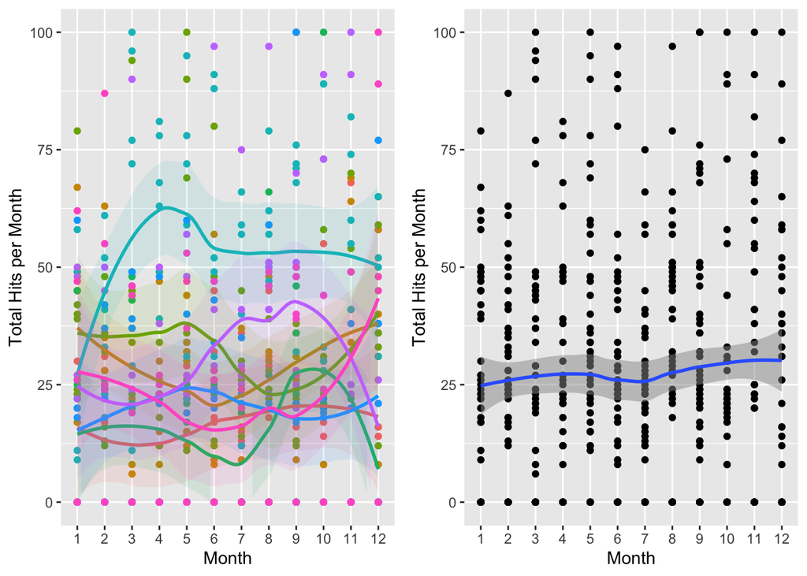

```r
# Visualize data monthwise
bykeyword <- ggplot(monthdat,aes(x=month,y=month_sum,color=keyword)) + geom_point(aes(fill=keyword)) +
  scale_x_discrete(name ="Month", limits=c("1","2","3",'4','5','6','7','8','9','10','11','12')) +
  geom_smooth(method="loess",aes(fill=keyword),alpha = 0.1) + theme(legend.position='none') +
  scale_y_continuous("Total Hits per Month",limits = c(0, 100))

total <- ggplot(monthdat,aes(x=month,y=month_sum)) + geom_point(aes(fill=keyword)) +
  scale_x_discrete(name ="Month", limits=c("1","2","3",'4','5','6','7','8','9','10','11','12')) +
  geom_smooth(method="loess",alpha = 0.5) + theme(legend.position='none') +
  scale_y_continuous("Total Hits per Month",limits = c(0, 100))

grid.arrange(bykeyword,total,ncol=2)
```

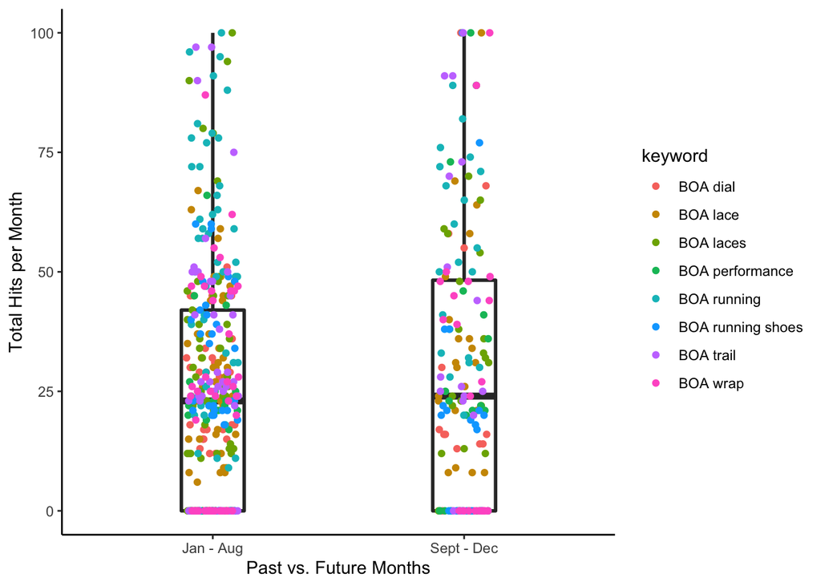

```r
# Split into two groups (before Sept & Sept and after)
avgs <- monthdat %>%
  group_by(month > 8)
colnames(avgs) <- c("keyword", "month","month_sum","future")

ggplot(avgs,aes(x=month>8,y=month_sum)) + geom_boxplot(outlier.alpha = 0.1,lwd=1,width=0.25) + geom_point(aes(color=keyword),position = position_jitterdodge(dodge.width=0.01,jitter.width = 0.2)) + theme(legend.position='none') + theme_classic() +   scale_x_discrete("Past vs. Future Months",labels = c("FALSE" = "Jan - Aug","TRUE" = "Sept - Dec")) + scale_y_continuous("Total Hits per Month")
```

```r
# Test for a major difference with a linear regression
summary(lm(data = avgs,formula = month_sum ~ future))
```

```
##
## Call:
## lm(formula = month_sum ~ future, data = avgs)
##
## Residuals:
##     Min      1Q  Median      3Q     Max
## -30.560 -26.177  -3.177  16.977  73.823
##
## Coefficients:
##             Estimate Std. Error t value Pr(>|t|)
## (Intercept)   26.177      1.295  20.218   <2e-16 ***
## futureTRUE     4.382      2.347   1.867   0.0624 .
## ---
## Signif. codes:  0 '***' 0.001 '**' 0.01 '*' 0.05 '.' 0.1 ' ' 1
##
## Residual standard error: 25.37 on 550 degrees of freedom
## Multiple R-squared:  0.0063, Adjusted R-squared:  0.004493
## F-statistic: 3.487 on 1 and 550 DF,  p-value: 0.06239
```

```r
  # No significant difference between past & future months
```

## How many days left in 2021?

```r
# t <- today()
t <- as.Date("2021-09-21") # Date of Tableau dashboard creation
s <- as.Date("2021-01-01")
done <- t-s
left <- 365-done

done <- as.numeric(done, units="days")
left <- as.numeric(left, units="days")

# Extrapolate for rest of 2021 and add to 2021 data so far for each keyword
extrap <- yeardat %>%
  group_by(keyword) %>%
  filter(year == 2021) %>%
  mutate(year_sum = year_sum + ((year_sum/done)*left))

extrap$year_sum <- round(extrap$year_sum) # Round to nearest integer
head(extrap)
```

| keyword | year | year_sum |
| --- | --- | --- |
| BOA dial | 2021 | 346 |
| BOA lace | 2021 | 609 |
| BOA laces | 2021 | 597 |
| BOA performance | 2021 | 169 |
| BOA running | 2021 | 693 |
| BOA running shoes | 2021 | 412 |

```r
# Estimated total for 2021
sum(extrap$year_sum)
```

```
## [1] 3592
```

## Possible next steps:

- Extrapolate the number of hits anticipated for Oct, Nov and Dec for each keyword, using the trendlines created with previous years’ data and the data for Jan - Sept of 2021
- Investigate whether certain keywords have a cyclic trend across the months of a year (i.e., do searches for “BOA + trail” increase in summer or winter, or stay relatively constant across the year?)

## Now let’s examine searches for a specific shoe with and without BOA terms, the La Sportiva Cyklon:

```r
# Load keywords list (.csv file)
setwd('/Users/melissamazzo/Documents/Data Sets')
kwlist <- readLines("KWlist_BOACyklon.csv")

# The function wrap all the arguments of the gtrendR::trends function and return only the interest_over_time
googleTrendsData <- function (keywords) {

  # Set the geographic region, time span, etc.
  country <- c("")
  time <- ("2016-01-01 2021-09-21")
  channel <- 'web'

  trends <- gtrends(keywords,
                   gprop = channel,
                   geo = country,
                   time = time )

  results <- trends$interest_over_time
  }

# googleTrendsData function is executed over the kwlist
output <- map_dfr(.x = kwlist,
                  .f = googleTrendsData )

# Download the dataframe "output" as a .csv file
write.csv(output, "BOARunning_Cyklon.csv")
```

## If data scraping was already performed, load CSV data for Cyklon instead:

```r
  # Cyklon
  output <- read.csv('BOARunning_Trends_Cyklon.csv')
  output$date <- as.Date(output$date)
```

## Connect Tableau workbook to CSV data sources